# CS 504 Project-3 (Data Mining)

Project Title: Classifying wines based on various features

Sagar Goswami  
Individual 25  
Data Analytics Engineering, George Mason University  
CS-504-002: Principles of Data Management and Mining  
G-Number: G01334430  
May 9, 2022  
In guidance of: Dr. Ping Deng

Github Link: https://github.com/GoswamiSagarD/Classification-Wine-Database-CS-504-Project-3

# Initialization

```python
# Importing required Libraries

import pandas as pd
import numpy as np
import seaborn as sns
```

```python
# Loading the data

headings = [
    'class', 'alcohol', 'malic_acid', 'ash', 'ash_alcalinity', 'magnesium',
    'tot_phenols', 'flavanoids', 'non_flavanoid-phenols', 'proanthocyanins',
    'color_intensity', 'hue', 'diluted_wines_0D280_0D315', 'proline'
]

wine = pd.read_csv( 'wine.csv', names=headings )
```

# Data Exploration

```python
wine
```

|  | class | alcohol | malic_acid | ash | ash_alcalinity | magnesium | tot_phenols | flavanoids | non_flavanoid-phenols | proanthocyanins | color_intensity | hue | diluted_wines_0D280_0D315 | proline |
| --- | --- | --- | --- | --- | --- | --- | --- | --- | --- | --- | --- | --- | --- | --- |
| 0 | 1 | 14.23 | 1.71 | 2.43 | 15.6 | 127 | 2.80 | 3.06 | 0.28 | 2.29 | 5.64 | 1.04 | 3.92 | 1065 |
| 1 | 1 | 13.20 | 1.78 | 2.14 | 11.2 | 100 | 2.65 | 2.76 | 0.26 | 1.28 | 4.38 | 1.05 | 3.40 | 1050 |
| 2 | 1 | 13.16 | 2.36 | 2.67 | 18.6 | 101 | 2.80 | 3.24 | 0.30 | 2.81 | 5.68 | 1.03 | 3.17 | 1185 |
| 3 | 1 | 14.37 | 1.95 | 2.50 | 16.8 | 113 | 3.85 | 3.49 | 0.24 | 2.18 | 7.80 | 0.86 | 3.45 | 1480 |
| 4 | 1 | 13.24 | 2.59 | 2.87 | 21.0 | 118 | 2.80 | 2.69 | 0.39 | 1.82 | 4.32 | 1.04 | 2.93 | 735 |
| ... | ... | ... | ... | ... | ... | ... | ... | ... | ... | ... | ... | ... | ... | ... |
| 173 | 3 | 13.71 | 5.65 | 2.45 | 20.5 | 95 | 1.68 | 0.61 | 0.52 | 1.06 | 7.70 | 0.64 | 1.74 | 740 |
| 174 | 3 | 13.40 | 3.91 | 2.48 | 23.0 | 102 | 1.80 | 0.75 | 0.43 | 1.41 | 7.30 | 0.70 | 1.56 | 750 |
| 175 | 3 | 13.27 | 4.28 | 2.26 | 20.0 | 120 | 1.59 | 0.69 | 0.43 | 1.35 | 10.20 | 0.59 | 1.56 | 835 |
| 176 | 3 | 13.17 | 2.59 | 2.37 | 20.0 | 120 | 1.65 | 0.68 | 0.53 | 1.46 | 9.30 | 0.60 | 1.62 | 840 |
| 177 | 3 | 14.13 | 4.10 | 2.74 | 24.5 | 96 | 2.05 | 0.76 | 0.56 | 1.35 | 9.20 | 0.61 | 1.60 | 560 |

178 rows × 14 columns

Here, the class is a categorical variable, whereas all the features are numeric data.

```python
# Checking Null Values in the dataframe
print('Count of Null Values in the Database:')
print(
    wine.isnull().sum()
)
```

```
Count of Null Values in the Database:
class                        0
alcohol                      0
malic_acid                   0
ash                          0
ash_alcalinity               0
magnesium                    0
tot_phenols                  0
flavanoids                   0
non_flavanoid-phenols        0
proanthocyanins              0
color_intensity              0
hue                          0
diluted_wines_0D280_0D315    0
proline                      0
dtype: int64
```

```python
wine.info()
```

```
<class 'pandas.core.frame.DataFrame'>
RangeIndex: 178 entries, 0 to 177
Data columns (total 14 columns):
 #   Column                     Non-Null Count  Dtype
---  ------                     --------------  -----
 0   class                      178 non-null    int64
 1   alcohol                    178 non-null    float64
 2   malic_acid                 178 non-null    float64
 3   ash                        178 non-null    float64
 4   ash_alcalinity             178 non-null    float64
 5   magnesium                  178 non-null    int64
 6   tot_phenols                178 non-null    float64
 7   flavanoids                 178 non-null    float64
 8   non_flavanoid-phenols      178 non-null    float64
 9   proanthocyanins            178 non-null    float64
 10  color_intensity            178 non-null    float64
 11  hue                        178 non-null    float64
 12  diluted_wines_0D280_0D315  178 non-null    float64
 13  proline                    178 non-null    int64
dtypes: float64(11), int64(3)
memory usage: 19.6 KB
```

```python
wine.describe().transpose()
```

|  | count | mean | std | min | 25% | 50% | 75% | max |
| --- | --- | --- | --- | --- | --- | --- | --- | --- |
| class | 178.0 | 1.938202 | 0.775035 | 1.00 | 1.0000 | 2.000 | 3.0000 | 3.00 |
| alcohol | 178.0 | 13.000618 | 0.811827 | 11.03 | 12.3625 | 13.050 | 13.6775 | 14.83 |
| malic_acid | 178.0 | 2.336348 | 1.117146 | 0.74 | 1.6025 | 1.865 | 3.0825 | 5.80 |
| ash | 178.0 | 2.366517 | 0.274344 | 1.36 | 2.2100 | 2.360 | 2.5575 | 3.23 |
| ash_alcalinity | 178.0 | 19.494944 | 3.339564 | 10.60 | 17.2000 | 19.500 | 21.5000 | 30.00 |
| magnesium | 178.0 | 99.741573 | 14.282484 | 70.00 | 88.0000 | 98.000 | 107.0000 | 162.00 |
| tot_phenols | 178.0 | 2.295112 | 0.625851 | 0.98 | 1.7425 | 2.355 | 2.8000 | 3.88 |
| flavanoids | 178.0 | 2.029270 | 0.998859 | 0.34 | 1.2050 | 2.135 | 2.8750 | 5.08 |
| non_flavanoid-phenols | 178.0 | 0.361854 | 0.124453 | 0.13 | 0.2700 | 0.340 | 0.4375 | 0.66 |
| proanthocyanins | 178.0 | 1.590899 | 0.572359 | 0.41 | 1.2500 | 1.555 | 1.9500 | 3.58 |
| color_intensity | 178.0 | 5.058090 | 2.318286 | 1.28 | 3.2200 | 4.690 | 6.2000 | 13.00 |
| hue | 178.0 | 0.957449 | 0.228572 | 0.48 | 0.7825 | 0.965 | 1.1200 | 1.71 |
| diluted_wines_0D280_0D315 | 178.0 | 2.611685 | 0.709990 | 1.27 | 1.9375 | 2.780 | 3.1700 | 4.00 |
| proline | 178.0 | 746.893258 | 314.907474 | 278.00 | 500.5000 | 673.500 | 985.0000 | 1680.00 |

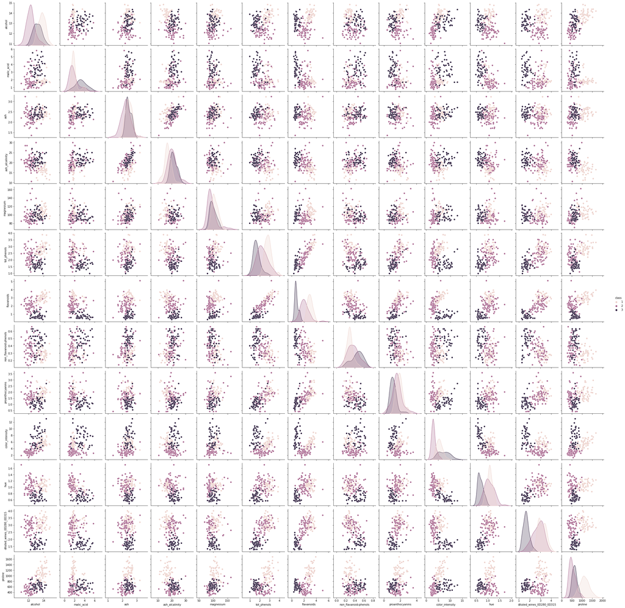

```python
# Visualizing Data Distribution of wine class against the wine features
sns.pairplot( wine, hue='class')
```

As seen in distribution plots above, following features provide the **best distinction among wine classes**:

- alcohol
- tot_phenols
- flavanoids

Whereas, following features provide adequate distinction with some overlap among the wine classes:

- malic_acid
- non_flavanoid_phenols
- hue
- diluted_wines_0D280_0D315
- proline

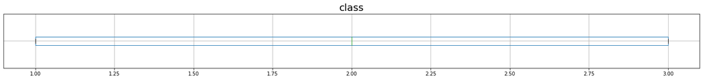

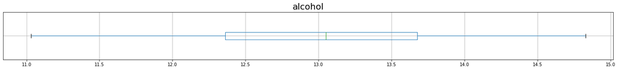

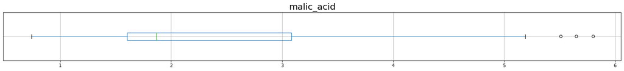

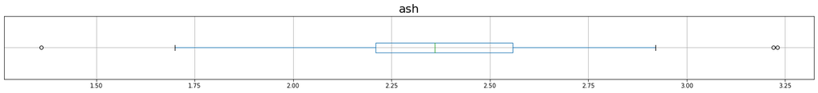

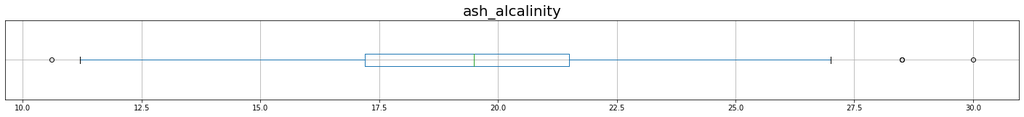

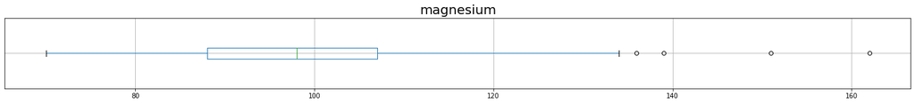

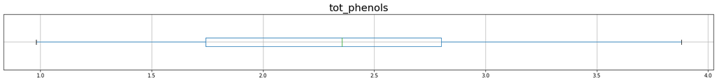

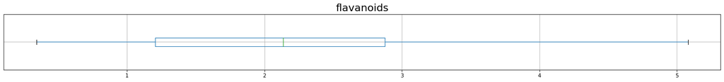

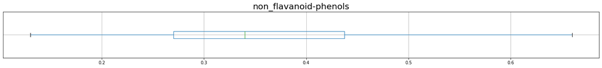

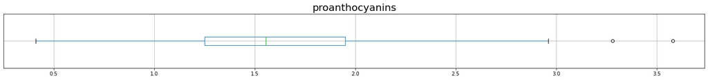

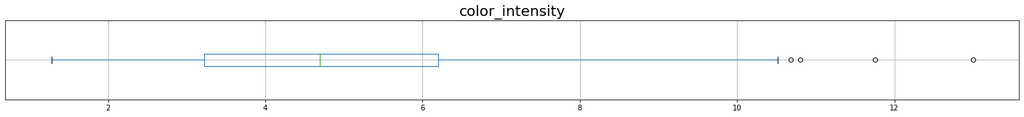

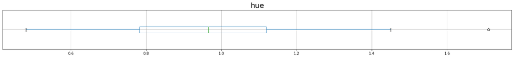

[2 more figures not shown]

```python
# Analyzing Data Distribution for all variables
import matplotlib.pyplot as plt

for column in wine:
    plt.figure( figsize=(25,2) )
    wine.boxplot( [column], vert=False )
    plt.title( column, fontsize=20 )
    plt.tick_params(labelleft=False, left=False)
    plt.show()
```

### Data Preprocessing

From the above box-plots, a few outliers can be detected, which affects the model performance. By comparing model performance before and after removing these outliers, a slight improvement in model accuracy was observed when removing the following points.

```python
# Performing following data cleaning operations improved the overall scores for many subsequent models

wine = wine.query(" \
    malic_acid < 5.3 & \
    ash < 3 & \
    ash_alcalinity < 27.5 & \
    magnesium < 135 & \
    proanthocyanins < 3 & \
    color_intensity < 10.5 & \
    hue < 1.5"
)
wine
```

|  | class | alcohol | malic_acid | ash | ash_alcalinity | magnesium | tot_phenols | flavanoids | non_flavanoid-phenols | proanthocyanins | color_intensity | hue | diluted_wines_0D280_0D315 | proline |
| --- | --- | --- | --- | --- | --- | --- | --- | --- | --- | --- | --- | --- | --- | --- |
| 0 | 1 | 14.23 | 1.71 | 2.43 | 15.6 | 127 | 2.80 | 3.06 | 0.28 | 2.29 | 5.64 | 1.04 | 3.92 | 1065 |
| 1 | 1 | 13.20 | 1.78 | 2.14 | 11.2 | 100 | 2.65 | 2.76 | 0.26 | 1.28 | 4.38 | 1.05 | 3.40 | 1050 |
| 2 | 1 | 13.16 | 2.36 | 2.67 | 18.6 | 101 | 2.80 | 3.24 | 0.30 | 2.81 | 5.68 | 1.03 | 3.17 | 1185 |
| 3 | 1 | 14.37 | 1.95 | 2.50 | 16.8 | 113 | 3.85 | 3.49 | 0.24 | 2.18 | 7.80 | 0.86 | 3.45 | 1480 |
| 4 | 1 | 13.24 | 2.59 | 2.87 | 21.0 | 118 | 2.80 | 2.69 | 0.39 | 1.82 | 4.32 | 1.04 | 2.93 | 735 |
| ... | ... | ... | ... | ... | ... | ... | ... | ... | ... | ... | ... | ... | ... | ... |
| 172 | 3 | 14.16 | 2.51 | 2.48 | 20.0 | 91 | 1.68 | 0.70 | 0.44 | 1.24 | 9.70 | 0.62 | 1.71 | 660 |
| 174 | 3 | 13.40 | 3.91 | 2.48 | 23.0 | 102 | 1.80 | 0.75 | 0.43 | 1.41 | 7.30 | 0.70 | 1.56 | 750 |
| 175 | 3 | 13.27 | 4.28 | 2.26 | 20.0 | 120 | 1.59 | 0.69 | 0.43 | 1.35 | 10.20 | 0.59 | 1.56 | 835 |
| 176 | 3 | 13.17 | 2.59 | 2.37 | 20.0 | 120 | 1.65 | 0.68 | 0.53 | 1.46 | 9.30 | 0.60 | 1.62 | 840 |
| 177 | 3 | 14.13 | 4.10 | 2.74 | 24.5 | 96 | 2.05 | 0.76 | 0.56 | 1.35 | 9.20 | 0.61 | 1.60 | 560 |

161 rows × 14 columns

```python
# Changing datatype for class column to string
wine['class'] = wine['class'].astype('string')

# Creating new dataframes to store class and features for wine database
wine_class = wine['class']
wine_features = wine[ wine.columns[1:] ]

# Creating training and testing sets
from sklearn.model_selection import train_test_split
x_train, x_test, y_train, y_test = train_test_split(
    wine_features, wine_class,
    test_size=0.25, random_state=30, shuffle=True
)

print('\nSize of Training and Testing Sets:\n')
print('Training Set    ', str( len(x_train) ))
print('Testing Set     ', str( len(x_test) ))
```

```
Size of Training and Testing Sets:

Training Set     120
Testing Set      41
```

# Decision Tree

### Simple Tree Model

**Resources:**

- https://scikit-learn.org/stable/modules/generated/sklearn.model_selection.train_test_split.html?highlight=train_test_split#sklearn.model_selection.train_test_split
- https://scikit-learn.org/stable/modules/tree.html

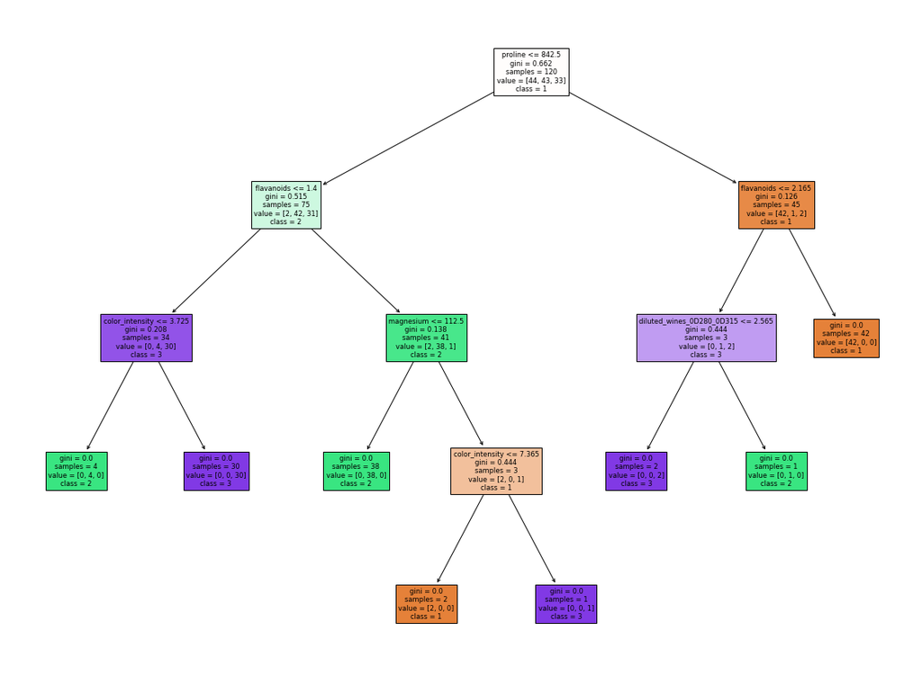

```
The accuracy of Decision Tree Model is:
92.6829268292683
```

```python
from sklearn import tree
from sklearn.model_selection import train_test_split

# Training Decison Tree Classifier Model on training set
clf_dt = tree.DecisionTreeClassifier().fit( x_train, y_train )

# Visualizing the Decision Tree Classifier Model
plt.figure( figsize=(20,15) )
tree.plot_tree( clf_dt, feature_names=wine.columns[1:], class_names='123', filled=True )
plt.show()

# Calculating Model Accuracy for Decision Tree on testing set
print("The accuracy of Decision Tree Model is:")
acc_dt = clf_dt.score( x_test, y_test ) * 100
print( acc_dt )
```

### Decision Tree with 10-Fold Cross-Validation

**Resources:**

- https://scikit-learn.org/stable/modules/cross_validation.html#

```python
from sklearn.model_selection import cross_val_score
from statistics import mean

# Performing 10-Fold Cross Validation on Decision Tree Model
cv_score_dt = cross_val_score( clf_dt, wine_features, wine_class, cv=10 )

# Calculating Model Accuracies obtained from Cross Validation
print("The Accuracy obtained from performing 10-Fold Cross Validation are:")
print( list ( cv_score_dt * 100 ) )

print("\nThe mean accuracy % from 10-Fold Cross Validation is:")
acc_dt_10cv = cv_score_dt.mean() * 100
print( acc_dt_10cv )

print("\nThe maximum accuracy % from 10-Fold Cross Validation is:")
print( cv_score_dt.max() * 100 )
```

```
The Accuracy obtained from performing 10-Fold Cross Validation are:
[82.35294117647058, 93.75, 75.0, 87.5, 75.0, 100.0, 93.75, 93.75, 93.75, 81.25]

The mean accuracy % from 10-Fold Cross Validation is:
87.61029411764707

The maximum accuracy % from 10-Fold Cross Validation is:
100.0
```

# Random Forest

### Simple Random Forest Model

**Resources:**

- https://scikit-learn.org/stable/modules/ensemble.html#forests-of-randomized-trees

```python
from sklearn.ensemble import RandomForestClassifier

# Training Random Forest Classifier Model on training set
clf_rf = RandomForestClassifier( n_estimators=10 )
clf_rf = clf_rf.fit( x_train, y_train )

# Calculating Model Accuracy for Random Forest
print("The accuracy % of Random Forest is:")
acc_rf = clf_rf.score ( x_test, y_test ) * 100
print( acc_rf )
```

```
The accuracy % of Random Forest is:
97.5609756097561
```

### Random Forest with 10-Fold Cross-Validation

**Resources:**

- https://scikit-learn.org/stable/modules/ensemble.html#forests-of-randomized-trees

```python
# Performing 10-Fold Cross Validation on Random Forest Model
cv_score_rf = cross_val_score( clf_rf, wine_features, wine_class, cv=10 )

# Calculating Model Accuracies obtained from Cross Validation
print("The Accuracy obtained from performing 10-Fold Cross Validation are:")
print( list ( cv_score_rf * 100 ) )

print("\nThe mean accuracy % from 10-Fold Cross Validation is:")
acc_rf_10cv = cv_score_rf.mean() * 100
print( acc_rf_10cv )

print("\nThe maximum accuracy % from 10-Fold Cross Validation is:")
print( cv_score_rf.max() * 100 )
```

```
The Accuracy obtained from performing 10-Fold Cross Validation are:
[100.0, 81.25, 100.0, 87.5, 100.0, 100.0, 100.0, 100.0, 100.0, 100.0]

The mean accuracy % from 10-Fold Cross Validation is:
96.875

The maximum accuracy % from 10-Fold Cross Validation is:
100.0
```

### Extremely Randomized Trees with 10-Fold Cross-Validation

**Resources:**

- https://scikit-learn.org/stable/modules/ensemble.html#forests-of-randomized-trees

```python
from sklearn.ensemble import ExtraTreesClassifier

# Performing 10-Fold Cross Validation on Extremely Randomized Tree Models
clf_et = ExtraTreesClassifier( n_estimators=10 )
cv_score_et = cross_val_score( clf_et, wine_features, wine_class, cv=10 )

# Calculating Model Accuracies obtained from Cross Validation
print("The Accuracy obtained from performing 10-Fold Cross Validation are:")
print( list ( cv_score_et * 100 ) )

print("\nThe mean accuracy % from 10-Fold Cross Validation is:")
acc_et_10_cv = cv_score_et.mean() * 100
print( acc_et_10_cv )

print("\nThe maximum accuracy % from 10-Fold Cross Validation is:")
print( cv_score_et.max() * 100 )
```

```
The Accuracy obtained from performing 10-Fold Cross Validation are:
[94.11764705882352, 93.75, 93.75, 100.0, 100.0, 100.0, 100.0, 100.0, 93.75, 100.0]

The mean accuracy % from 10-Fold Cross Validation is:
97.53676470588235

The maximum accuracy % from 10-Fold Cross Validation is:
100.0
```

### Random Forest vs Decision Trees Comparision

**Accruracy from Decision Tree Models are:**

- Decision Tree w/holdoffs 92.68 %
- Decision Tree w/CV 87.61 %

**Whereas, accuracy obtained from Random Forest Models are:**

- Random Forest w/holdoffs 97.56 %
- Random Forest w/CV 96.87 %
- Extremely Randomized Tree w/CV 97.53 %

There appears to be a sharp increase in accuracy (9%) when using Random Forest, instead of a single tree. Additionally, randomizing the trees gives further 0.7% increase in accuracy.

# K-Nearest Neighbors

### KNN Preprocessing

Since, K-Nearest Neighbors is very succeptible to noise due to excessive features, only best features are selected for classification. Moreover, KNN requires the data to be in the standardized form, to negate the effects of high-magnitude values in any chosen variable.

From the pair-plots in the Data Exploration section above, **(alcohol, tot_phenols, flavanoids)** provided the best distinction among wine classes, while **(malic_acid, non_flavanoid_phenols, hue, diluted_wines_0D280_0D315, proline)** provided adequate distinction with some overlap.

**Resources**

- https://scikit-learn.org/stable/modules/preprocessing.html#:~:text=6.3.3.%20Normalization%C2%B6
- https://scikit-learn.org/stable/modules/generated/sklearn.preprocessing.normalize.html#sklearn.preprocessing.normalize

```python
# Creating new dataframes to store best features for wine database
wine_best_features = wine[ wine.columns[[1, 6, 7, 2, 8, 11, 12, 13]] ]
```

```python
# Vectorization
x_vec = wine_best_features.to_numpy()
y_vec = wine_class.to_numpy()

# Normalizing all features in the wine dataset
from sklearn.preprocessing import normalize
x_vec = normalize( x_vec )
```

### KNN (k=10) with 10-Fold Cross-Validation

```python
import matplotlib.pyplot as plt
from matplotlib.colors import ListedColormap
from sklearn import neighbors

# Performing 10-Fold Cross Validation on K-Nearest Neighbor Model
clf_knn = neighbors.KNeighborsClassifier( n_neighbors=10 )
cv_score_knn = cross_val_score( clf_knn, x_vec, y_vec, cv=10 )

# Calculating Model Accuracies obtained from Cross Validation
print("The Accuracy obtained from performing 10-Fold Cross Validation are:")
print( list ( cv_score_knn * 100 ) )

print("\nThe mean accuracy % from 10-Fold Cross Validation is:")
acc_knn_10cv = cv_score_knn.mean() * 100
print( acc_knn_10cv )

print("\nThe maximum accuracy % from 10-Fold Cross Validation is:")
print( cv_score_knn.max() * 100 )
```

```
The Accuracy obtained from performing 10-Fold Cross Validation are:
[94.11764705882352, 93.75, 93.75, 87.5, 87.5, 87.5, 93.75, 87.5, 87.5, 87.5]

The mean accuracy % from 10-Fold Cross Validation is:
90.03676470588235

The maximum accuracy % from 10-Fold Cross Validation is:
94.11764705882352
```

### KNN for k (0 to 50) with 10-Fold Cross-Validation

```python
# Calculating mean accuracy from 10-Fold Cross Validation for each value of k between 1 and 50.
cv_score_50_knn = pd.DataFrame( columns=['k','Accuracy'] )
for k in range(1, 51):
    clf_50_knn = neighbors.KNeighborsClassifier( n_neighbors=k )
    cv_score = cross_val_score(clf_50_knn, x_vec, y_vec, cv=10).mean() * 100
    cv_score_50_knn.loc[ len(cv_score_50_knn) ] = [ k, cv_score ]

# Calculating Model Accuracies obtained from Cross Validation
print("The mean accuracy from 10-Fold Cross Validation for each value of k between 1 and 50 are:")
print( cv_score_50_knn )

print("\nThe mean accuracy % from 10-Fold Cross Validation for best k:")
acc_knn_best_k_10_cv = cv_score_50_knn[ cv_score_50_knn.Accuracy==cv_score_50_knn.Accuracy.max() ]
print( acc_knn_best_k_10_cv )
acc_knn_best_k_10_cv = cv_score_50_knn.Accuracy.max()
```

```
The mean accuracy from 10-Fold Cross Validation for each value of k between 1 and 50 are:
       k   Accuracy
0    1.0  89.411765
1    2.0  90.073529
2    3.0  88.198529
3    4.0  88.161765
4    5.0  88.823529
5    6.0  88.823529
6    7.0  89.411765
7    8.0  91.286765
8    9.0  88.161765
9   10.0  90.036765
10  11.0  88.161765
11  12.0  88.161765
12  13.0  89.411765
```

[output cut: 41 more lines]

### K-Nearest Neighbor vs Random Forest vs Decision Trees Comparision

[NOTE: KNN is highly succeptible to noise, as higher number of features in the model translates to higher chances of overfitting the model on random noise. Hence, only selected features were used to improve the model accuracy. In contrary, rest of the algorithms include some form of feature selection, thereby not requiring manual intervention for feature selection.]

**Accuracy obtained from Random Forest Models are:**

- Random Forest w/holdoffs 97.56 %
- Random Forest w/CV 96.87 %
- Extremely Randomized Tree w/CV 97.53 %

**Whereas, accuracy obtained from K-Nearest Models are:**

- K-nearest w/CV 90.04 % @ k=10
- K-Nearest k from 0 to 50 w/CV 91.29 % @ k=8 (best k)

Accuracy for K-nearest Model with k=10 is 7% lower than the Random Forest Model, and 7.5% lower than the Extremely Randomized Tree Model. Upon training multiple models with different values of k, the best accuracy obtained was 91% at k=8 (best k), which is 1.25% higher than k=10 model. The plausible cause for low model performance is the high dimensionality, which is one of the biggest drawbacks of KNN. The accuracy of the model can be further improved by iterating the model training over various pairs of features.

# Naive Bayes

*Resources*

- https://scikit-learn.org/stable/modules/naive_bayes.html#:~:text=1.9.2.%20Multinomial%20Naive%20Bayes%C2%B6
- https://scikit-learn.org/stable/modules/generated/sklearn.naive_bayes.MultinomialNB.html#sklearn.naive_bayes.MultinomialNB

```python
from sklearn.naive_bayes import MultinomialNB

# Performing 10-Fold Cross Validation on Multinomial Naive Bayes Model
clf_mnb = MultinomialNB()
cv_score_mnb = cross_val_score( clf_mnb, wine_features, wine_class, cv=10 )

# Calculating Model Accuracies obtained from Cross Validation
print("The Accuracy obtained from performing 10-Fold Cross Validation are: \n")
print( list(cv_score_mnb * 100) )

print("\nThe mean accuracy % from 10-Fold Cross Validation is:")
acc_mnb_10_cv = cv_score_mnb.mean() * 100
print( acc_mnb_10_cv )

print("\nThe maximum accuracy % from 10-Fold Cross Validation is:")
print( cv_score_mnb.max() * 100 )
```

```
The Accuracy obtained from performing 10-Fold Cross Validation are:

[70.58823529411765, 81.25, 81.25, 81.25, 75.0, 100.0, 75.0, 93.75, 100.0, 93.75]

The mean accuracy % from 10-Fold Cross Validation is:
85.18382352941177

The maximum accuracy % from 10-Fold Cross Validation is:
100.0
```

### Gaussian Naive Bayes with 10-Fold Cross-Validation

*Resources*

- https://scikit-learn.org/stable/modules/naive_bayes.html#:~:text=1.9.1.%20Gaussian%20Naive%20Bayes%C2%B6
- https://scikit-learn.org/stable/modules/generated/sklearn.naive_bayes.GaussianNB.html#sklearn.naive_bayes.GaussianNB

```python
from sklearn.naive_bayes import GaussianNB

# Performing 10-Fold Cross Validation on Gaussian Naive Bayes Model
clf_mnb = GaussianNB()
cv_score_gnb = cross_val_score( clf_mnb, wine_features, wine_class, cv=10 )

# Calculating Model Accuracies obtained from Cross Validation
print("The Accuracy obtained from performing 10-Fold Cross Validation are: \n")
print( list(cv_score_gnb * 100) )

print("\nThe mean accuracy % from 10-Fold Cross Validation is:")
acc_gnb_10_cv = cv_score_gnb.mean() * 100
print( acc_gnb_10_cv )

print("\nThe maximum accuracy % from 10-Fold Cross Validation is:")
print( cv_score_gnb.max() * 100 )
```

```
The Accuracy obtained from performing 10-Fold Cross Validation are:

[100.0, 93.75, 100.0, 93.75, 100.0, 93.75, 100.0, 93.75, 100.0, 100.0]

The mean accuracy % from 10-Fold Cross Validation is:
97.5

The maximum accuracy % from 10-Fold Cross Validation is:
100.0
```

```python
acc_gnb_10_cv - acc_mnb_10_cv
```

```
12.316176470588232
```

### GaussianNB vs MultiNomialNB model comparision:

**Mean Accuracy from Multinomial Naive Bayes Classificaiton Model with 10-Fold Cross Validation is:**

- MultinomialNB w/CV 85.18 %

**Whereas, Mean Accuracy obtained from Gaussian Naive Bayes Classificaiton Model with 10-Fold Cross Validation is:**

- GaussianNB w/CV 97.50 %

There is a huge increase in model classification accuracy (12%) when using Gaussian model instead of Mulinomial. The cause for such a steep difference could be that, Multinomial Naive Bayes Algorithm is more suitable for variables that indicate frequency of occurences or counts, as opposed to Gaussian Naive Bayes algorithm which is suitable for all continuous Ratio-numeric data.

**Source:** *https://www.i2tutorials.com/what-is-the-difference-between-gaussian-multinomial-and-bernoulli-naive-bayes-classifiers/*

# Support Vector Machines

### SVM Model by Radial Basis Function (RBF) with 10-Fold Cross-Validation

**Resources**

- https://scikit-learn.org/stable/modules/svm.html

```python
from sklearn.svm import SVC

# Performing 10-Fold Cross Validation on SVM Model by rbf (radial basis function)
clf_svc = SVC()
cv_score_svc = cross_val_score( clf_svc, wine_features, wine_class, cv=10 )

# Calculating Model Accuracies obtained from Cross Validation
print("The Accuracy obtained from performing 10-Fold Cross Validation are: \n")
print( list(cv_score_svc * 100) )

print("\nThe mean accuracy % from 10-Fold Cross Validation is:")
acc_svc_rbf_10_cv = cv_score_svc.mean() * 100
print( acc_svc_rbf_10_cv )

print("\nThe maximum accuracy % from 10-Fold Cross Validation is:")
print( cv_score_svc.max() * 100 )
```

```
The Accuracy obtained from performing 10-Fold Cross Validation are:

[58.82352941176471, 68.75, 75.0, 62.5, 75.0, 81.25, 62.5, 75.0, 81.25, 81.25]

The mean accuracy % from 10-Fold Cross Validation is:
72.13235294117646

The maximum accuracy % from 10-Fold Cross Validation is:
81.25
```

### SVM Model by testing various kernels with 10-Fold Cross-Validation

**Resources**

- https://scikit-learn.org/stable/modules/generated/sklearn.svm.SVC.html#sklearn.svm.SVC

```python
# Calculating mean accuracy from 10-Fold Cross Validation for linear, sigmoid and poly kernels
svm_kernels = ['linear', 'sigmoid', 'poly']
cv_score_k_svm = pd.DataFrame( columns=['kernel','Accuracy'] )

for k in svm_kernels:
    clf_k_svm = SVC( kernel=k )
    cv_score = cross_val_score( clf_k_svm, wine_features, wine_class, cv=10 ).mean() * 100
    cv_score_k_svm.loc[ len(cv_score_k_svm) ] = [ k, cv_score ]

# Calculating Model Accuracies obtained from Cross Validation
print("The mean Accuracy obtained by all kernels from performing 10-Fold Cross Validation are: \n")
print( cv_score_k_svm )

print("\nThe maximum accuracy % from all kernels with 10-Fold Cross Validation is:")
print( cv_score_k_svm[ cv_score_k_svm.Accuracy==cv_score_k_svm.Accuracy.max() ])
acc_svc_lin_10_cv = cv_score_k_svm.Accuracy[0]
acc_svc_sig_10_cv = cv_score_k_svm.Accuracy[1]
acc_svc_pol_10_cv = cv_score_k_svm.Accuracy[2]
```

```
The mean Accuracy obtained by all kernels from performing 10-Fold Cross Validation are:

    kernel   Accuracy
0   linear  95.073529
1  sigmoid  16.176471
2     poly  71.470588

The maximum accuracy % from all kernels with 10-Fold Cross Validation is:
   kernel   Accuracy
0  linear  95.073529
```

# Conclusion

### Comparing all the Classification Models

```python
acc = pd.DataFrame(data=
    {
        'Model': ['Decision Tree', 'Decision Tree 10 CV', 'Random Forest', 'Random Forest 10 CV', 'Extremely Randomized Tree 10 CV',
        'KNN 10 CV', 'KNN Best K 10 CV', 'Multinomial NB 10 CV', 'Gaussian NB 10 CV', 'SVM RBF 10 CV', 'SVM Linear 10 CV', 'SVM Sigmoid 10 CV', 'SVM Poly 10 CV'],
        'Accuracy': [acc_dt, acc_dt_10cv, acc_rf, acc_rf_10cv, acc_et_10_cv, acc_knn_10cv, acc_knn_best_k_10_cv, acc_mnb_10_cv, acc_gnb_10_cv,
        acc_svc_rbf_10_cv, acc_svc_lin_10_cv, acc_svc_sig_10_cv, acc_svc_pol_10_cv]
    }
)

acc
```

|  | Model | Accuracy |
| --- | --- | --- |
| 0 | Decision Tree | 92.682927 |
| 1 | Decision Tree 10 CV | 87.610294 |
| 2 | Random Forest | 97.560976 |
| 3 | Random Forest 10 CV | 96.875000 |
| 4 | Extremely Randomized Tree 10 CV | 97.536765 |
| 5 | KNN 10 CV | 90.036765 |
| 6 | KNN Best K 10 CV | 91.286765 |
| 7 | Multinomial NB 10 CV | 85.183824 |
| 8 | Gaussian NB 10 CV | 97.500000 |
| 9 | SVM RBF 10 CV | 72.132353 |
| 10 | SVM Linear 10 CV | 95.073529 |
| 11 | SVM Sigmoid 10 CV | 16.176471 |
| 12 | SVM Poly 10 CV | 71.470588 |

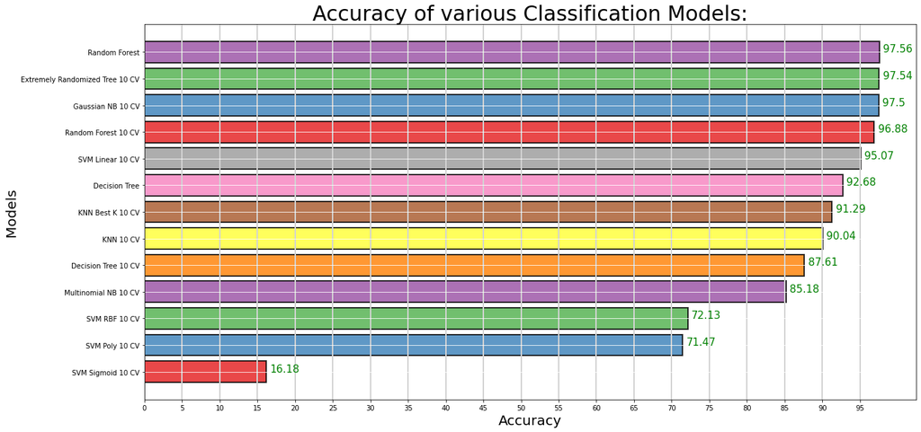

```python
acc = acc.sort_values( by='Accuracy', ascending=True )


fig, ax = plt.subplots( figsize=(20,10) )
col_map = plt.get_cmap('Set1')

plt.grid(axis = 'x', color='lightgrey', linewidth=2)
plt.grid(axis='y', color='white')
x_ticks = np.arange(0, 100, 5)
ax.set_xticks(x_ticks)

plt.barh( acc.Model, acc.Accuracy, color=col_map.colors, alpha=0.8, edgecolor='black', linewidth=2 )

plt.title( 'Accuracy of various Classification Models:', fontsize=30)
plt.xlabel( 'Accuracy', fontsize=20 )
plt.ylabel( 'Models', fontsize=20 )
for i, v in enumerate(acc.Accuracy):
    plt.text( x =v+0.5, y = i, s = str( round(v, ndigits=2)), fontsize=15, color='green' )
plt.show()
```

### Final Result

Among all the classification models trained on wine data, following models provide the best classification accuracy for the wine data:

[output not shown]